# Project 2

Kristina Golden and Demetrios Samaras 2023-07-02

# Lifestyle

## Required Packages

```r
library(tidyverse)
library(knitr)
library(GGally)
library(corrplot)
library(qwraps2)
library(vtable)
library(psych)
library(ggplot2)
library(cowplot)
library(caret)
library(gbm)
library(randomForest)
library(tree)
library(class)
library(bst)
library(reshape)
library(reshape2)
library(corrr)
library(ggcorrplot)
library(FactoMineR)
library(factoextra)
library(data.table)
```

## Read in the Data

```r
#setwd("C:/Documents/Github/ST_558_Project_2")
setwd("C:/Users/Demetri/Documents/NCSU_masters/ST558/Repos/ST_558_project_2_pages")


online <- read.csv("OnlineNewsPopularity.csv")
colnames(online) <- c('url', 'days', 'n.Title', 'n.Content', 'Rate.Unique',
                      'Rate.Nonstop', 'Rate.Unique.Nonstop', 'n.Links',
                      'n.Other', 'n.Images', 'n.Videos',
                      'Avg.Words', 'n.Key', 'Lifestyle', 'Entertainment',
                      'Business', 'Social.Media', 'Tech', 'World', 'Min.Worst.Key',
                      'Max.Worst.Key', 'Avg.Worst.Key', 'Min.Best.Key',
                      'Max.Best.Key', 'Avg.Best.Key', 'Avg.Min.Key', 'Avg.Max.Key',
                      'Avg.Avg.Key', 'Min.Ref', 'Max.Ref', 'Avg.Ref', 'Mon',
                      'Tues', 'Wed', 'Thurs', 'Fri', 'Sat', 'Sun', 'Weekend',
                      'LDA_00', 'LDA_01', 'LDA_02', 'LDA_03', 'LDA_04',
                      'Global.Subj', 'Global.Pol', 'Global.Pos.Rate',
                      'Global.Neg.Rate', 'Rate.Pos', 'Rate.Neg', 'Avg.Pos.Pol',
                      'Min.Pos.Pol', 'Max.Pos.Pol', 'Avg.Neg.Pol', 'Min.Neg.Pol',
                      'Max.Neg.Pol', 'Title.Subj', 'Title.Pol', 'Abs.Subj',
                      'Abs.Pol', 'shares')
#Dropped url and timedelta because they are non-predictive.
online <- online[ , c(3:61)]
```

## Write Functions

```r
summary_table <- function(data_input) {
    min <- min(data_input$shares)
    q1 <- quantile(data_input$shares, 0.25)
    med <- median(data_input$shares)
    q3 <- quantile(data_input$shares, 0.75)
    max <- max(data_input$shares)
    mean1 <- mean(data_input$shares)
    sd1 <- sd(data_input$shares)
    data <- matrix(c(min, q1, med, q3, max, mean1, sd1),
                   ncol=1)
    rownames(data) <- c("Minimum", "Q1", "Median", "Q3",
                           "Maximum", "Mean", "SD")
    colnames(data) <- c('Shares')
    data <- as.table(data)
    data
}
```

```r
#Create correlation table and graph for a training dataset
correlation_table <- function(data_input) {
  #drop binary variables
  correlations <- cor(subset(data_input, select = c(2:4, 6:24,
                                                    33:50)))
  kable(correlations, caption = 'Correlations Lifestyle')
}
```

```r
# Create correlation graph
correlation_graph <- function(data_input,sig=0.5){
  corr <- cor(subset(data_input, select = c(2:4, 6:24, 33:50)))
  corr[lower.tri(corr, diag = TRUE)] <- NA
  corr <- melt(corr, na.rm = TRUE)
  corr <- subset(corr, abs(value) > 0.5)
  corr[order(-abs(corr$value)),]
  print(corr)
  mtx_corr <- reshape2::acast(corr, Var1~Var2, value.var="value")
  corrplot(mtx_corr, is.corr=FALSE, tl.col="black", na.label=" ")
}
```

## Lifestyle EDA

### Lifestyle

```r
## filters rows based on when parameter is 1
data_channel <-  online %>% filter( !!rlang::sym(params$DataChannel) == 1)

## Drop the data_channel_is columns
data_channel <- data_channel[ , -c(12:17)]

## reorder to put shares first
data_channel <- data_channel[ , c(53, 1:52)]
```

```r
set.seed(5432)

# Split the data into a training and test set (70/30 split)
# indices

train <- sample(1:nrow(data_channel), size = nrow(data_channel)*.70)
test <- setdiff(1:nrow(data_channel), train)

# training and testing subsets
data_channel_train <- data_channel[train, ]
data_channel_test <- data_channel[test, ]
```

## Lifestyle Summarizations

```r
#Shares table for data_channel_train
summary_table(data_channel_train)
```

```
##             Shares
## Minimum     28.000
## Q1        1100.000
## Median    1700.000
## Q3        3200.000
## Maximum 208300.000
## Mean      3770.660
## SD        9802.024
```

The above table displays the Lifestyle 5-number summary for the shares. It also includes the mean and standard deviation. Because the mean is greater than the median, we suspect that the Lifestyle shares distribution is right skewed.

```r
#Correlation table for lifestyle_train
correlation_table(data_channel_train)
```

Correlations Lifestyle

|  | n.Title | n.Content | Rate.Unique | Rate.Unique.Nonstop | n.Links | n.Other | n.Images | n.Videos | Avg.Words | n.Key | Min.Worst.Key | Max.Worst.Key | Avg.Worst.Key | Min.Best.Key | Max.Best.Key | Avg.Best.Key | Avg.Min.Key | Avg.Max.Key | Avg.Avg.Key | Min.Ref | Max.Ref | Avg.Ref | LDA_00 | LDA_01 | LDA_02 | LDA_03 | LDA_04 | Global.Subj | Global.Pol | … |
| --- | --- | --- | --- | --- | --- | --- | --- | --- | --- | --- | --- | --- | --- | --- | --- | --- | --- | --- | --- | --- | --- | --- | --- | --- | --- | --- | --- | --- | --- | --- |
| n.Title | 1.0000000 | 0.0110788 | -0.0299399 | -0.0292103 | -0.1102683 | 0.0184994 | -0.0152067 | -0.0029681 | -0.0779939 | -0.0798863 | -0.0530870 | 0.0228746 | -0.0063953 | 0.0053470 | 0.0749129 | 0.1409165 | -0.0032850 | -0.0026321 | 0.0162808 | 0.0512335 | 0.0313824 | 0.0512142 | -0.0366395 | 0.0821186 | 0.0708543 | -0.0077871 | -0.0171024 | -0.0710700 | -0.0834255 | … |
| n.Content | 0.0110788 | 1.0000000 | -0.5179230 | -0.3651876 | 0.3015521 | 0.1900089 | 0.4879406 | 0.0441036 | 0.0292420 | 0.0801110 | -0.1164249 | 0.0161783 | -0.0073094 | 0.0690303 | 0.1137872 | 0.0687721 | 0.0881707 | 0.0694450 | 0.1122453 | -0.0001303 | 0.0419563 | 0.0254683 | 0.0678206 | -0.0261978 | -0.0200444 | 0.0766760 | -0.0939653 | 0.1077615 | 0.0835293 | … |
| Rate.Unique | -0.0299399 | -0.5179230 | 1.0000000 | 0.9148541 | -0.2252921 | -0.1121176 | -0.2907981 | 0.0098843 | 0.5806017 | -0.1369419 | 0.0984607 | -0.0452506 | -0.0133399 | -0.0579483 | -0.0892984 | -0.0931308 | -0.0307488 | -0.0613592 | -0.1081669 | 0.0401228 | 0.0020135 | 0.0276824 | -0.0473955 | 0.0433955 | 0.0001542 | -0.1149242 | 0.1051411 | 0.2524087 | 0.0133601 | … |
| Rate.Unique.Nonstop | -0.0292103 | -0.3651876 | 0.9148541 | 1.0000000 | -0.2702140 | -0.0887240 | -0.3862216 | 0.0092625 | 0.6010723 | -0.1676945 | 0.0939193 | -0.0386260 | -0.0075402 | -0.0642482 | -0.0831774 | -0.1280242 | -0.0741199 | -0.0769582 | -0.1510221 | 0.0218479 | 0.0041338 | 0.0189516 | 0.0034647 | 0.0377854 | 0.0146458 | -0.2348051 | 0.1418084 | 0.2823969 | 0.0047847 | … |
| n.Links | -0.1102683 | 0.3015521 | -0.2252921 | -0.2702140 | 1.0000000 | 0.2731710 | 0.4347634 | 0.0525431 | 0.1684971 | 0.2121596 | -0.1556713 | 0.0162698 | -0.0158459 | 0.1451405 | 0.1578786 | 0.1424023 | 0.1842874 | 0.1368765 | 0.2488977 | 0.0209764 | 0.0569355 | 0.0468429 | 0.0431287 | -0.0718110 | -0.1521932 | 0.2922028 | -0.1580693 | 0.2636678 | 0.2133331 | … |
| n.Other | 0.0184994 | 0.1900089 | -0.1121176 | -0.0887240 | 0.2731710 | 1.0000000 | 0.1927763 | 0.0275531 | 0.0575709 | 0.1700062 | 0.0919840 | 0.0535872 | 0.0635467 | -0.0193591 | -0.1175320 | -0.1427653 | -0.0287098 | 0.0129269 | -0.0487213 | -0.0196695 | 0.1449863 | 0.0725963 | -0.0194528 | 0.0700835 | -0.1214614 | -0.0178995 | 0.0513940 | 0.0601585 | 0.1097929 | … |
| n.Images | -0.0152067 | 0.4879406 | -0.2907981 | -0.3862216 | 0.4347634 | 0.1927763 | 1.0000000 | -0.0564529 | -0.0526545 | 0.1686526 | -0.0852350 | -0.0262038 | -0.0533502 | 0.1134689 | 0.0895906 | 0.1483794 | 0.2003450 | 0.1057878 | 0.2498931 | 0.0487033 | 0.0357119 | 0.0488944 | -0.0680730 | -0.0453094 | -0.1259183 | 0.4469373 | -0.1902649 | 0.1905937 | 0.1665748 | … |
| n.Videos | -0.0029681 | 0.0441036 | 0.0098843 | 0.0092625 | 0.0525431 | 0.0275531 | -0.0564529 | 1.0000000 | -0.0065006 | 0.0282615 | -0.0650308 | 0.0638704 | 0.0441592 | 0.0398809 | 0.0617208 | 0.1339735 | 0.0822040 | 0.0404606 | 0.0865687 | 0.0444637 | 0.0773941 | 0.0901189 | -0.0188324 | 0.0177442 | 0.0159725 | 0.1309176 | -0.0865452 | 0.0294136 | -0.0028593 | … |
| Avg.Words | -0.0779939 | 0.0292420 | 0.5806017 | 0.6010723 | 0.1684971 | 0.0575709 | -0.0526545 | -0.0065006 | 1.0000000 | -0.0682157 | -0.0137871 | -0.0289138 | -0.0123988 | -0.0200969 | 0.0171693 | -0.0356107 | -0.0092119 | -0.0139737 | -0.0466133 | 0.0513336 | 0.0498184 | 0.0601413 | 0.0013526 | 0.0569821 | 0.0326765 | -0.1179866 | 0.0497412 | 0.4640439 | 0.1273103 | … |
| n.Key | -0.0798863 | 0.0801110 | -0.1369419 | -0.1676945 | 0.2121596 | 0.1700062 | 0.1686526 | 0.0282615 | -0.0682157 | 1.0000000 | -0.0104367 | 0.0773855 | 0.0634731 | -0.2127384 | 0.0174993 | -0.2122350 | -0.0892582 | 0.1121536 | 0.0617402 | -0.0012785 | 0.0492774 | 0.0310070 | -0.0346407 | -0.0882956 | -0.0859854 | 0.1543315 | -0.0168012 | 0.0637236 | 0.1047512 | … |
| Min.Worst.Key | -0.0530870 | -0.1164249 | 0.0984607 | 0.0939193 | -0.1556713 | 0.0919840 | -0.0852350 | -0.0650308 | -0.0137871 | -0.0104367 | 1.0000000 | -0.0123741 | 0.0862958 | -0.1489727 | -0.8500828 | -0.6625509 | -0.2158033 | -0.1556491 | -0.3569635 | -0.1011064 | -0.0710016 | -0.1060488 | -0.1253085 | 0.0208687 | -0.0987232 | -0.1579040 | 0.2446405 | -0.0501244 | 0.0320797 | … |
| Max.Worst.Key | 0.0228746 | 0.0161783 | -0.0452506 | -0.0386260 | 0.0162698 | 0.0535872 | -0.0262038 | 0.0638704 | -0.0289138 | 0.0773855 | -0.0123741 | 1.0000000 | 0.9655514 | -0.0228100 | 0.0132328 | -0.0174607 | 0.0137639 | 0.6391081 | 0.4456136 | 0.1504116 | 0.0672183 | 0.1242983 | 0.0528339 | -0.0079449 | -0.0169306 | 0.0448496 | -0.0664643 | -0.0459174 | -0.0223359 | … |
| Avg.Worst.Key | -0.0063953 | -0.0073094 | -0.0133399 | -0.0075402 | -0.0158459 | 0.0635467 | -0.0533502 | 0.0441592 | -0.0123988 | 0.0634731 | 0.0862958 | 0.9655514 | 1.0000000 | -0.0684150 | -0.0881542 | -0.1402515 | -0.0367375 | 0.5949281 | 0.3715555 | 0.1255725 | 0.0517452 | 0.1005389 | 0.0460335 | 0.0105437 | -0.0207235 | 0.0174941 | -0.0464199 | -0.0549471 | -0.0254125 | … |
| Min.Best.Key | 0.0053470 | 0.0690303 | -0.0579483 | -0.0642482 | 0.1451405 | -0.0193591 | 0.1134689 | 0.0398809 | -0.0200969 | -0.2127384 | -0.1489727 | -0.0228100 | -0.0684150 | 1.0000000 | 0.1675304 | 0.3838225 | 0.6122509 | 0.0974074 | 0.3377193 | 0.0342756 | 0.0216771 | 0.0358632 | -0.0119451 | -0.0882911 | -0.0878536 | 0.2268611 | -0.0853481 | 0.0740544 | 0.0122909 | … |
| Max.Best.Key | 0.0749129 | 0.1137872 | -0.0892984 | -0.0831774 | 0.1578786 | -0.1175320 | 0.0895906 | 0.0617208 | 0.0171693 | 0.0174993 | -0.8500828 | 0.0132328 | -0.0881542 | 0.1675304 | 1.0000000 | 0.7491632 | 0.2479284 | 0.1709345 | 0.4164029 | 0.1089041 | 0.0674822 | 0.1088258 | 0.1238430 | -0.0283992 | 0.0766902 | 0.1561092 | -0.2314683 | 0.0459958 | -0.0248400 | … |
| Avg.Best.Key | 0.1409165 | 0.0687721 | -0.0931308 | -0.1280242 | 0.1424023 | -0.1427653 | 0.1483794 | 0.1339735 | -0.0356107 | -0.2122350 | -0.6625509 | -0.0174607 | -0.1402515 | 0.3838225 | 0.7491632 | 1.0000000 | 0.4166685 | 0.1891409 | 0.5142181 | 0.1195559 | 0.0705410 | 0.1195094 | 0.0689336 | -0.0830480 | 0.1001356 | 0.3265935 | -0.2943553 | 0.0346292 | -0.0655842 | … |
| Avg.Min.Key | -0.0032850 | 0.0881707 | -0.0307488 | -0.0741199 | 0.1842874 | -0.0287098 | 0.2003450 | 0.0822040 | -0.0092119 | -0.0892582 | -0.2158033 | 0.0137639 | -0.0367375 | 0.6122509 | 0.2479284 | 0.4166685 | 1.0000000 | 0.1222672 | 0.4982819 | 0.0930471 | 0.0577062 | 0.0923088 | -0.0105216 | -0.1105513 | -0.0787477 | 0.3078109 | -0.1387305 | 0.1311119 | 0.0397544 | … |
| Avg.Max.Key | -0.0026321 | 0.0694450 | -0.0613592 | -0.0769582 | 0.1368765 | 0.0129269 | 0.1057878 | 0.0404606 | -0.0139737 | 0.1121536 | -0.1556491 | 0.6391081 | 0.5949281 | 0.0974074 | 0.1709345 | 0.1891409 | 0.1222672 | 1.0000000 | 0.8176412 | 0.1794584 | 0.0758021 | 0.1445484 | 0.0440211 | -0.0337027 | -0.0579297 | 0.2038838 | -0.1453924 | 0.0294655 | 0.0112614 | … |
| Avg.Avg.Key | 0.0162808 | 0.1122453 | -0.1081669 | -0.1510221 | 0.2488977 | -0.0487213 | 0.2498931 | 0.0865687 | -0.0466133 | 0.0617402 | -0.3569635 | 0.4456136 | 0.3715555 | 0.3377193 | 0.4164029 | 0.5142181 | 0.4982819 | 0.8176412 | 1.0000000 | 0.2242091 | 0.1066172 | 0.1938360 | 0.0536526 | -0.0867497 | -0.0960957 | 0.4372132 | -0.2834008 | 0.0974915 | 0.0241415 | … |
| Min.Ref | 0.0512335 | -0.0001303 | 0.0401228 | 0.0218479 | 0.0209764 | -0.0196695 | 0.0487033 | 0.0444637 | 0.0513336 | -0.0012785 | -0.1011064 | 0.1504116 | 0.1255725 | 0.0342756 | 0.1089041 | 0.1195559 | 0.0930471 | 0.1794584 | 0.2242091 | 1.0000000 | 0.4150517 | 0.7939819 | -0.0384189 | -0.0008907 | 0.0026171 | 0.0837293 | -0.0263836 | 0.0566861 | -0.0228452 | … |
| Max.Ref | 0.0313824 | 0.0419563 | 0.0020135 | 0.0041338 | 0.0569355 | 0.1449863 | 0.0357119 | 0.0773941 | 0.0498184 | 0.0492774 | -0.0710016 | 0.0672183 | 0.0517452 | 0.0216771 | 0.0674822 | 0.0705410 | 0.0577062 | 0.0758021 | 0.1066172 | 0.4150517 | 1.0000000 | 0.8743617 | 0.0171107 | -0.0042371 | -0.0215135 | 0.0539991 | -0.0422989 | 0.0507336 | -0.0165495 | … |
| Avg.Ref | 0.0512142 | 0.0254683 | 0.0276824 | 0.0189516 | 0.0468429 | 0.0725963 | 0.0488944 | 0.0901189 | 0.0601413 | 0.0310070 | -0.1060488 | 0.1242983 | 0.1005389 | 0.0358632 | 0.1088258 | 0.1195094 | 0.0923088 | 0.1445484 | 0.1938360 | 0.7939819 | 0.8743617 | 1.0000000 | -0.0086979 | -0.0026341 | -0.0124719 | 0.0871836 | -0.0475061 | 0.0662716 | -0.0278423 | … |
| LDA_00 | -0.0366395 | 0.0678206 | -0.0473955 | 0.0034647 | 0.0431287 | -0.0194528 | -0.0680730 | -0.0188324 | 0.0013526 | -0.0346407 | -0.1253085 | 0.0528339 | 0.0460335 | -0.0119451 | 0.1238430 | 0.0689336 | -0.0105216 | 0.0440211 | 0.0536526 | -0.0384189 | 0.0171107 | -0.0086979 | 1.0000000 | -0.0924699 | -0.0945770 | -0.1425409 | -0.6752992 | 0.0158890 | 0.0483707 | … |
| LDA_01 | 0.0821186 | -0.0261978 | 0.0433955 | 0.0377854 | -0.0718110 | 0.0700835 | -0.0453094 | 0.0177442 | 0.0569821 | -0.0882956 | 0.0208687 | -0.0079449 | 0.0105437 | -0.0882911 | -0.0283992 | -0.0830480 | -0.1105513 | -0.0337027 | -0.0867497 | -0.0008907 | -0.0042371 | -0.0026341 | -0.0924699 | 1.0000000 | -0.0568733 | -0.1185211 | -0.1444150 | -0.0272238 | -0.0841993 | … |
| LDA_02 | 0.0708543 | -0.0200444 | 0.0001542 | 0.0146458 | -0.1521932 | -0.1214614 | -0.1259183 | 0.0159725 | 0.0326765 | -0.0859854 | -0.0987232 | -0.0169306 | -0.0207235 | -0.0878536 | 0.0766902 | 0.1001356 | -0.0787477 | -0.0579297 | -0.0960957 | 0.0026171 | -0.0215135 | -0.0124719 | -0.0945770 | -0.0568733 | 1.0000000 | -0.1675496 | -0.1605881 | -0.1519091 | -0.1442637 | … |
| LDA_03 | -0.0077871 | 0.0766760 | -0.1149242 | -0.2348051 | 0.2922028 | -0.0178995 | 0.4469373 | 0.1309176 | -0.1179866 | 0.1543315 | -0.1579040 | 0.0448496 | 0.0174941 | 0.2268611 | 0.1561092 | 0.3265935 | 0.3078109 | 0.2038838 | 0.4372132 | 0.0837293 | 0.0539991 | 0.0871836 | -0.1425409 | -0.1185211 | -0.1675496 | 1.0000000 | -0.4710863 | 0.1462446 | 0.0899032 | … |
| LDA_04 | -0.0171024 | -0.0939653 | 0.1051411 | 0.1418084 | -0.1580693 | 0.0513940 | -0.1902649 | -0.0865452 | 0.0497412 | -0.0168012 | 0.2446405 | -0.0664643 | -0.0464199 | -0.0853481 | -0.2314683 | -0.2943553 | -0.1387305 | -0.1453924 | -0.2834008 | -0.0263836 | -0.0422989 | -0.0475061 | -0.6752992 | -0.1444150 | -0.1605881 | -0.4710863 | 1.0000000 | -0.0488074 | -0.0214089 | … |
| Global.Subj | -0.0710700 | 0.1077615 | 0.2524087 | 0.2823969 | 0.2636678 | 0.0601585 | 0.1905937 | 0.0294136 | 0.4640439 | 0.0637236 | -0.0501244 | -0.0459174 | -0.0549471 | 0.0740544 | 0.0459958 | 0.0346292 | 0.1311119 | 0.0294655 | 0.0974915 | 0.0566861 | 0.0507336 | 0.0662716 | 0.0158890 | -0.0272238 | -0.1519091 | 0.1462446 | -0.0488074 | 1.0000000 | 0.3787183 | … |
| Global.Pol | -0.0834255 | 0.0835293 | 0.0133601 | 0.0047847 | 0.2133331 | 0.1097929 | 0.1665748 | -0.0028593 | 0.1273103 | 0.1047512 | 0.0320797 | -0.0223359 | -0.0254125 | 0.0122909 | -0.0248400 | -0.0655842 | 0.0397544 | 0.0112614 | 0.0241415 | -0.0228452 | -0.0165495 | -0.0278423 | 0.0483707 | -0.0841993 | -0.1442637 | 0.0899032 | -0.0214089 | 0.3787183 | 1.0000000 | … |
| Global.Pos.Rate | -0.0523560 | 0.1350869 | 0.0566932 | 0.1141509 | 0.1416339 | 0.0923294 | 0.0717974 | -0.0087140 | 0.2479148 | 0.0615604 | 0.0211998 | -0.0293952 | -0.0327381 | 0.0247461 | -0.0244808 | -0.0349774 | 0.0258048 | -0.0035017 | 0.0062952 | -0.0380946 | -0.0077857 | -0.0314937 | 0.0558411 | -0.0642573 | -0.0886695 | 0.0198979 | -0.0065381 | 0.3923134 | 0.5895064 | … |
| Global.Neg.Rate | -0.0055210 | 0.0426196 | 0.1158168 | 0.1740753 | -0.0486469 | -0.0893977 | -0.0377173 | 0.0285786 | 0.1521068 | -0.0189577 | -0.0698515 | -0.0254692 | -0.0292439 | 0.0324368 | 0.0612139 | 0.1037962 | 0.0707919 | -0.0052117 | 0.0583869 | 0.0367789 | 0.0142112 | 0.0285654 | -0.0067924 | 0.0355217 | 0.0648493 | 0.0676040 | -0.0769217 | 0.1605758 | -0.4433522 | … |
| Rate.Pos | -0.0430617 | 0.0918491 | 0.2495182 | 0.2945995 | 0.1539406 | 0.1488562 | 0.0159384 | -0.0105836 | 0.4911351 | 0.0079826 | 0.0573718 | -0.0140478 | -0.0035540 | -0.0150814 | -0.0485235 | -0.1221383 | -0.0380804 | -0.0156365 | -0.0724124 | -0.0121116 | 0.0075279 | -0.0038379 | 0.0406885 | -0.0311954 | -0.0841980 | -0.1143152 | 0.0866312 | 0.3588045 | 0.7117570 | … |
| Rate.Neg | 0.0029321 | -0.0018365 | 0.1840770 | 0.2212759 | -0.0671051 | -0.0852634 | -0.0604293 | 0.0137471 | 0.2045127 | -0.0570470 | -0.0714995 | -0.0158546 | -0.0149121 | 0.0153498 | 0.0648299 | 0.0899416 | 0.0456214 | -0.0030085 | 0.0370126 | 0.0585501 | 0.0242607 | 0.0504236 | -0.0361185 | 0.0663186 | 0.0713973 | 0.0205350 | -0.0322024 | 0.0717298 | -0.6582671 | … |
| Avg.Pos.Pol | -0.1196140 | 0.0949908 | 0.2384819 | 0.2671106 | 0.2194584 | 0.0345210 | 0.1687448 | 0.0309884 | 0.3997877 | 0.0598665 | -0.0453917 | -0.0290024 | -0.0311271 | 0.0372078 | 0.0419889 | 0.0164537 | 0.1101237 | 0.0294569 | 0.0841427 | 0.0413408 | 0.0194402 | 0.0304926 | 0.0468725 | -0.0478452 | -0.1015306 | 0.1362399 | -0.0800468 | 0.6014492 | 0.5557670 | … |
| Min.Pos.Pol | -0.0491722 | -0.2602193 | 0.3966118 | 0.2925506 | -0.0776824 | -0.0897591 | -0.0245293 | 0.0396286 | 0.1651019 | -0.0690784 | 0.0331360 | -0.0274479 | -0.0204647 | 0.0093497 | -0.0251637 | 0.0040643 | 0.0721179 | -0.0202984 | 0.0079605 | 0.0232514 | -0.0294225 | -0.0072903 | -0.0502997 | 0.0261569 | -0.0225624 | 0.0635211 | -0.0017975 | 0.1866792 | 0.0384956 | … |
| Max.Pos.Pol | -0.0511522 | 0.3462956 | -0.0824198 | 0.0281253 | 0.3235884 | 0.1130056 | 0.1806496 | 0.0522285 | 0.3188778 | 0.1031375 | -0.1255187 | -0.0045306 | -0.0241128 | 0.0768204 | 0.1163836 | 0.0704712 | 0.1079466 | 0.0830175 | 0.1359914 | 0.0413621 | 0.0601953 | 0.0570299 | 0.0952420 | -0.0340296 | -0.0662459 | 0.1007748 | -0.1138137 | 0.4444792 | 0.4683765 | … |
| Avg.Neg.Pol | 0.0051632 | -0.0954441 | -0.1147582 | -0.1662731 | -0.1061087 | -0.0268304 | -0.0820571 | -0.0182066 | -0.2219020 | 0.0143804 | 0.0485092 | 0.0172666 | 0.0194307 | -0.0182360 | -0.0360047 | -0.0492424 | -0.0406027 | -0.0318167 | -0.0634391 | -0.0569206 | -0.0604110 | -0.0720513 | -0.0059717 | 0.0042044 | -0.0033225 | -0.0559248 | 0.0435911 | -0.3509543 | 0.2205241 | … |
| Min.Neg.Pol | 0.0050987 | -0.3705757 | 0.1856373 | 0.0377063 | -0.1874251 | -0.0338315 | -0.1157283 | -0.0604697 | -0.1380138 | -0.0050009 | 0.1183023 | 0.0056211 | 0.0217172 | -0.0606313 | -0.1059019 | -0.1159985 | -0.0614843 | -0.0416312 | -0.0988982 | -0.0615751 | -0.0640542 | -0.0742014 | -0.0385988 | 0.0312447 | -0.0261636 | -0.0426125 | 0.0615219 | -0.2904059 | 0.2438137 | … |
| Max.Neg.Pol | -0.0142189 | 0.2324525 | -0.3259421 | -0.2461165 | 0.0498500 | 0.0239071 | 0.0443254 | 0.0255017 | -0.1653286 | 0.0388410 | -0.0255061 | 0.0085449 | -0.0016911 | 0.0182756 | 0.0193880 | 0.0028911 | -0.0132081 | -0.0155124 | -0.0135344 | -0.0373688 | -0.0075193 | -0.0298099 | 0.0189050 | 0.0039440 | 0.0340423 | -0.0442145 | 0.0006987 | -0.1076128 | -0.0191475 | … |
| Title.Subj | 0.0524284 | 0.0011818 | -0.0565348 | -0.0914118 | 0.0804441 | -0.0067873 | 0.1091487 | 0.0095681 | -0.0759752 | 0.0207470 | -0.0334011 | 0.0054758 | 0.0001296 | 0.0155010 | 0.0189116 | 0.0645839 | 0.0306132 | 0.0464990 | 0.0858472 | 0.0255218 | 0.0269942 | 0.0316989 | -0.0234951 | 0.0097185 | -0.0591908 | 0.1314129 | -0.0522189 | 0.1260644 | 0.0810606 | … |

The above table gives the correlations between all variables in the Lifestyle data set. This allows us to see which two variables have strong correlation. If we have two variables with a high correlation, we might want to remove one of them to avoid too much multicollinearity.

```
##                     Var1                Var2      value
## 82             n.Content         Rate.Unique -0.5179230
## 123          Rate.Unique Rate.Unique.Nonstop  0.9148541
## 323          Rate.Unique           Avg.Words  0.5806017
## 324  Rate.Unique.Nonstop           Avg.Words  0.6010723
## 492        Max.Worst.Key       Avg.Worst.Key  0.9655514
## 571        Min.Worst.Key        Max.Best.Key -0.8500828
## 611        Min.Worst.Key        Avg.Best.Key -0.6625509
## 615         Max.Best.Key        Avg.Best.Key  0.7491632
## 654         Min.Best.Key         Avg.Min.Key  0.6122509
## 692        Max.Worst.Key         Avg.Max.Key  0.6391081
## 693        Avg.Worst.Key         Avg.Max.Key  0.5949281
## 736         Avg.Best.Key         Avg.Avg.Key  0.5142181
## 738          Avg.Max.Key         Avg.Avg.Key  0.8176412
## 860              Min.Ref             Avg.Ref  0.7939819
## 861              Max.Ref             Avg.Ref  0.8743617
## 1063              LDA_00              LDA_04 -0.6752992
## 1189          Global.Pol     Global.Pos.Rate  0.5895064
## 1269          Global.Pol            Rate.Pos  0.7117570
## 1270     Global.Pos.Rate            Rate.Pos  0.5725193
## 1271     Global.Neg.Rate            Rate.Pos -0.5515355
## 1309          Global.Pol            Rate.Neg -0.6582671
## 1311     Global.Neg.Rate            Rate.Neg  0.8186061
## 1312            Rate.Pos            Rate.Neg -0.6872464
## 1348         Global.Subj         Avg.Pos.Pol  0.6014492
## 1349          Global.Pol         Avg.Pos.Pol  0.5557670
## 1434         Avg.Pos.Pol         Max.Pos.Pol  0.6353018
## 1517         Avg.Neg.Pol         Min.Neg.Pol  0.6966795
## 1557         Avg.Neg.Pol         Max.Neg.Pol  0.5503891
```

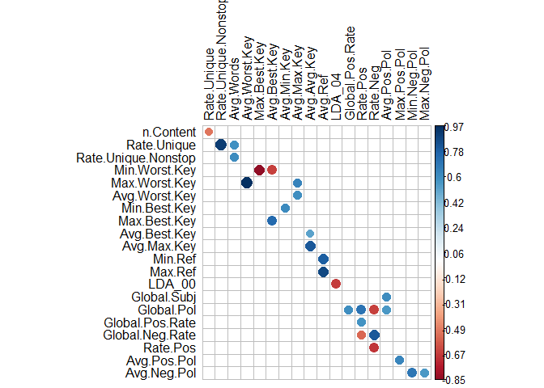

```r
#Correlation graph for lifestyle_train
correlation_graph(data_channel_train)
```

Because the correlation table above is large, it can be difficult to read. The correlation graph above gives a visual summary of the table. Using the legend, we are able to see the correlations between variables, how strong the correlation is, and in what direction.

```r
## mean of shares
mean(data_channel_train$shares)
```

```
## [1] 3770.66
```

```r
## sd of shares
sd(data_channel_train$shares)
```

```
## [1] 9802.024
```

```r
## creates a new column that is if shares is higher than average or not
shareshigh <- data_channel_train %>% select(shares) %>% mutate (shareshigh = (shares> mean(shares)))

## creates a contingency table of shareshigh and whether it is the weekend
table(shareshigh$shareshigh, data_channel_train$Weekend)
```

```
##
##           0   1
##   FALSE 941 211
##   TRUE  238  79
```

These above contingency tables will look at the shareshigh factor which says whether the number of shares is higher than the mean number of shares or not and compares it to the weekend. Using these we can see if the number of shares tends to be higher or not on the weekend.

```r
## creates a new column that is if shares is higher than average or not
shareshigh <- data_channel_train %>% mutate (shareshigh = (shares> mean(shares)))

## create a new column that combines Mon-Fri into weekdays
shareshigh <- mutate(shareshigh,
                  Weekday = ifelse(Mon == 1 |
                                     Tues ==1 |
                                     Wed == 1 |
                                     Thurs == 1 |
                                     Fri == 1,
                                    'Weekday', 'Weekend'))
shareshigh <- mutate(shareshigh,
                  Days_of_Week = ifelse(Mon == 1 &
                                Weekday == 'Weekday', 'Mon',
                              ifelse(Tues == 1  &
                                Weekday == "Weekday", 'Tues',
                              ifelse(Wed == 1 &
                                Weekday == "Weekday", 'Wed',
                              ifelse(Thurs ==1 &
                                Weekday == 'Weekday', 'Thurs',
                              ifelse(Fri == 1 &
                                       Weekday == 'Weekday',
                                     'Fri', 'Weekend'))))))

shareshigh$Days_of_Week <- ordered(shareshigh$Days_of_Week,
                                levels=c("Mon", "Tues",
                                         "Wed", "Thurs",
                                         "Fri", "Weekend"))

## creates a contingency table of shareshigh and whether it is a weekday
print(prop.table(table(shareshigh$Weekday,
                       shareshigh$shareshigh)))
```

```
##
##                FALSE       TRUE
##   Weekday 0.64057182 0.16201498
##   Weekend 0.14363513 0.05377808
```

The contingency table above looks at the before-mentioned shareshigh factor and compares it to the whether the day was a weekend or a weekday. This allows us to see if shares tend to be higher on weekends or weekdays. The frequencies are displayed as relative frequencies.

```r
## creates  a contingency table of shareshigh and the day of the week
a <- prop.table(table(shareshigh$Days_of_Week,
                 shareshigh$shareshigh))
b <- as.data.frame(a)
print(a)
```

```
##
##                FALSE       TRUE
##   Mon     0.11980939 0.03607897
##   Tues    0.13274336 0.03267529
##   Wed     0.14635807 0.03335602
##   Thurs   0.12389381 0.03607897
##   Fri     0.11776719 0.02382573
##   Weekend 0.14363513 0.05377808
```

After comparing shareshigh with whether or not the day was a weekend or weekday, the above contingency table compares shareshigh for each specific day of the week. Again, the frequencies are displayed as relative frequencies.

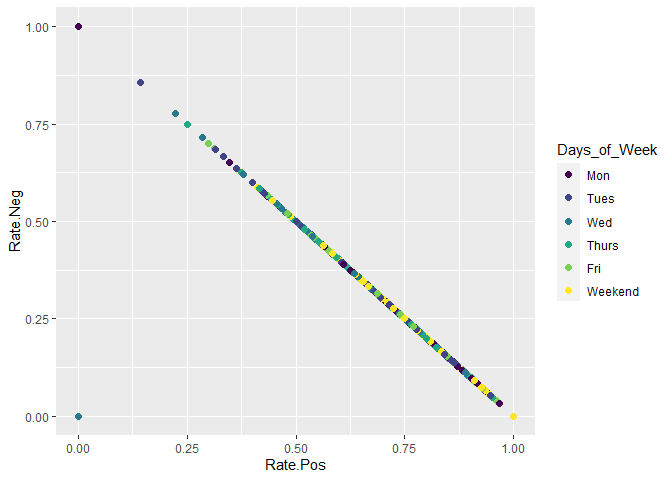

```r
ggplot(shareshigh, aes(x=Rate.Pos, y=Rate.Neg,
                       color=Days_of_Week)) +
    geom_point(size=2)
```

Once seeing the correlation table and graph, it is possible to graph two variables on a scatterplot. This provides a visual of the linear relationship. A scatterplot of two variables in the Lifestyle dataset has been created above.

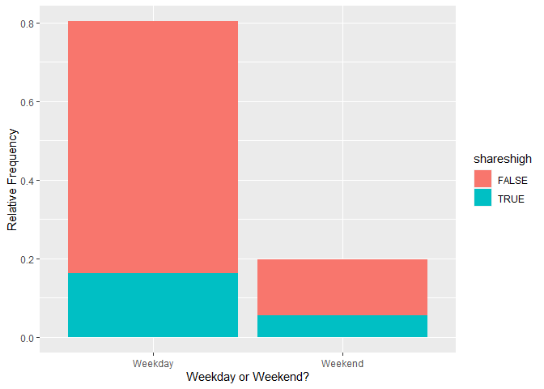

```r
ggplot(shareshigh, aes(x = Weekday, fill = shareshigh)) +
  geom_bar(aes(y = (after_stat(count))/sum(after_stat(count)))) + xlab('Weekday or Weekend?') +
  ylab('Relative Frequency')
```

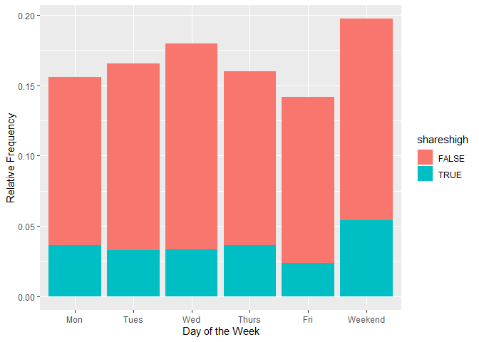

```r
ggplot(shareshigh, aes(x = Days_of_Week, fill = shareshigh)) +
  geom_bar(aes(y = (after_stat(count))/sum(after_stat(count)))) + xlab('Day of the Week') +
  ylab('Relative Frequency')
```

The above bar graphs are a visual representation of the contingency tables between weekends/weekdays and shareshigh and the days of the week and shareshigh.. Graphs can improve the stakeholders ability to interpret the results quickly.

```r
a <- table(shareshigh$Days_of_Week)
# a <- prop.table(table(shareshigh$Days_of_Week,
#                  shareshigh$shareshigh))
b <- as.data.frame(a)
colnames(b) <- c('Day of Week', 'Freq')
b <- filter(b, Freq == max(b$Freq))
d <- as.character(b[1,1])
g <- mutate(shareshigh,
                  Most_Freq = ifelse(Days_of_Week == d,
                                    'Most Freq Day',
                                    'Not Most Freq Day'
                                    ))
paste0(" For ",
        params$DataChannel, " ",
       d, " is the most frequent day of the week")
```

```
## [1] " For Lifestyle Weekend is the most frequent day of the week"
```

```r
table(shareshigh$shareshigh, g$Most_Freq)
```

```
##
##         Most Freq Day Not Most Freq Day
##   FALSE           211               941
##   TRUE             79               238
```

The above contingency table compares shareshigh to the Lifestyle day that occurs most frequently. This allows us to see if the most frequent day tends to have more shareshigh.

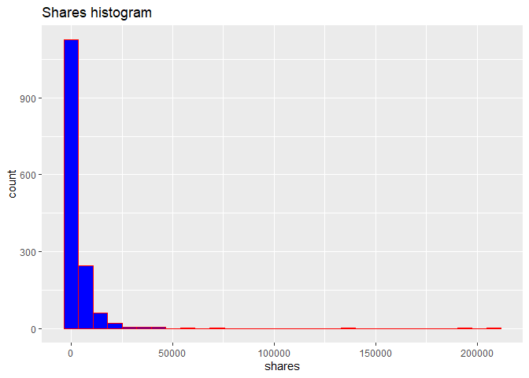

```r
## creates plotting object of shares
a <- ggplot(data_channel_train, aes(x=shares))

## histogram of shares
a+geom_histogram(color= "red", fill="blue")+ ggtitle("Shares histogram")
```

Above we can see the frequency distribution of shares of the Lifestyle data channel. We should always see a long tail to the right because a small number of articles will get a very high number of shares. But looking at by looking at the distribution we can say how many shares most of these articles got.

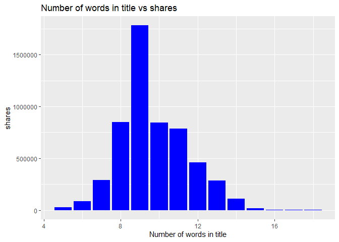

```r
## creates plotting object with number of words in title and shares
b<- ggplot(data_channel_train, aes(x=n.Title, y=shares))

## creates a bar chart with number of words in title and shares
b+ geom_col(fill="blue")+ ggtitle("Number of words in title vs shares") + labs(x="Number of words in title")
```

In the above graph we are looking at the number of shares based on how many words are in the title of the article. if we see a large peak on at the higher number of words it means for this data channel there were more shares on longer titles, and if we see a peak at smaller number of words then there were more shares on smaller titles.

```r
## makes correlation of every variable with shares
shares_correlations <- cor(data_channel_train)[1,] %>% sort()

shares_correlations
```

```
##              LDA_02         Rate.Unique       Min.Worst.Key         Min.Neg.Pol
##        -0.043485734        -0.037856182        -0.034898025        -0.034076505
##              LDA_01            Rate.Pos                 Fri              LDA_04
##        -0.032394351        -0.032320852        -0.031980585        -0.029743909
##           Avg.Words        Rate.Nonstop Rate.Unique.Nonstop                 Wed
##        -0.026994093        -0.024076078        -0.019812905        -0.019696013
##         Min.Pos.Pol             n.Title         Avg.Neg.Pol          Title.Subj
##        -0.019135505        -0.018277702        -0.018265755        -0.013562869
##          Global.Pol     Global.Pos.Rate           Title.Pol             n.Other
##        -0.012610714        -0.010636397        -0.009477268        -0.008281549
##             Abs.Pol                 Sun               Thurs             Max.Ref
##        -0.006215299        -0.004111683        -0.002608310         0.001749309
##        Min.Best.Key       Avg.Worst.Key         Max.Pos.Pol             Weekend
##         0.002301291         0.004011085         0.004280115         0.007222068
##       Max.Worst.Key                Tues             Avg.Ref     Global.Neg.Rate
##         0.008319178         0.008830561         0.010921075         0.012253552
##         Avg.Pos.Pol                 Sat         Global.Subj            Rate.Neg
##         0.014316988         0.014384138         0.015081424         0.016628897
##         Avg.Min.Key         Max.Neg.Pol             Min.Ref        Avg.Best.Key
##         0.017569402         0.020537567         0.021710065         0.023732033
##              LDA_00            Abs.Subj                 Mon               n.Key
##         0.028385175         0.037247613         0.037249116         0.037623093
##        Max.Best.Key             n.Links         Avg.Max.Key              LDA_03
##         0.038164872         0.039816547         0.047298460         0.047307228
##            n.Images           n.Content         Avg.Avg.Key            n.Videos
##         0.049282670         0.059916744         0.088706294         0.106405174
##              shares
##         1.000000000
```

```r
## take the name of the highest correlated variable
highest_cor <-shares_correlations[52]  %>% names()

highest_cor
```

```
## [1] "n.Videos"
```

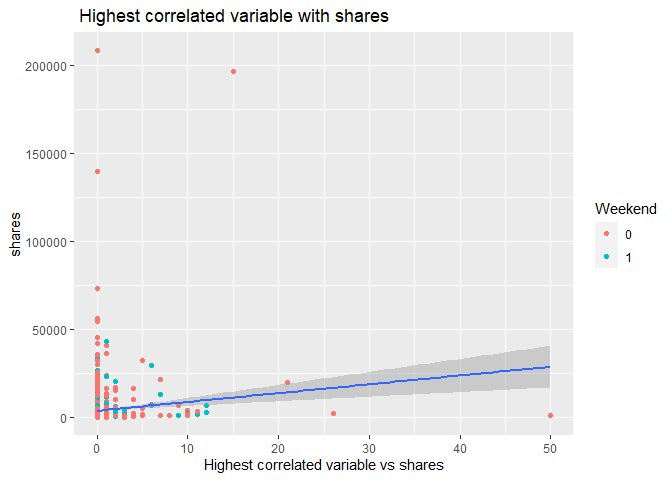

```r
## creats scatter plot looking at shares vs highest correlated variable
g <-ggplot(data_channel_train,  aes(y=shares, x= data_channel_train[[highest_cor]]))


g+ geom_point(aes(color=as.factor(Weekend))) +geom_smooth(method = lm) + ggtitle(" Highest correlated variable with shares") + labs(x="Highest correlated variable vs shares", color="Weekend")
```

The above graph looks at the relationship between shares and the variable with the highest correlation for the Lifestyle data channel, and colored based on whether or not it is the weekend. because this is the most positively correlated variable we should always see an upward trend but the more correlated they are the more the dots will fall onto the line of best fit.